# Social Network Analysis Home Assignment 4

due date - 19.06.2015 23:59

# Network Epidemics

Please send your reports to hse.ntwks@gmail.com with the subject of of the following structure:  
*[MAGOLEGO SNA 2015] {LastName} {First Name} HA{Number}*

Late submission policy: -1 point per day

Use this file as a template for your report.  
Support your computations with figures and comments. Send ONLY .Rmd versions of your report.

## SIR Model

You need to perform epidemic SIR model on different types of networks: Try different parameters for network generation

```r
gl <- list()
gl$ba <- barabasi.game(n = 100,m = 12 , directed=FALSE)
gl$er <- erdos.renyi.game(n = 250, p.or.m = 0.02, type=c("gnp"))
gl$ws <- watts.strogatz.game(dim = 1, size = 1000, nei = 3, p = 0.01)
```

Moreover perform modeling on real peer-to-peer network [here](https://www.dropbox.com/s/sto6dxyja0u7y4u/Net.txt?dl=0)

Your goal is to perform a research on epidemics: Use different values of parameters listed below

```r
beta <- 2
gamma <- 4
ntrials <- 100

# Running function sir for each element of list gl (list with graphs)
sim <- lapply(gl, sir, beta=beta, gamma=gamma, no.sim=ntrials)
```

at least 3 different versions, for example:

- betta (4 6 8)
- gamma (8 6 2)
- niter (100 500 1000)

*For some reason `beta` and `gamma` parameters should not be set below 0 and 1. Looks like they are somehow normilized during simulation.*

The code below can help you with plotting

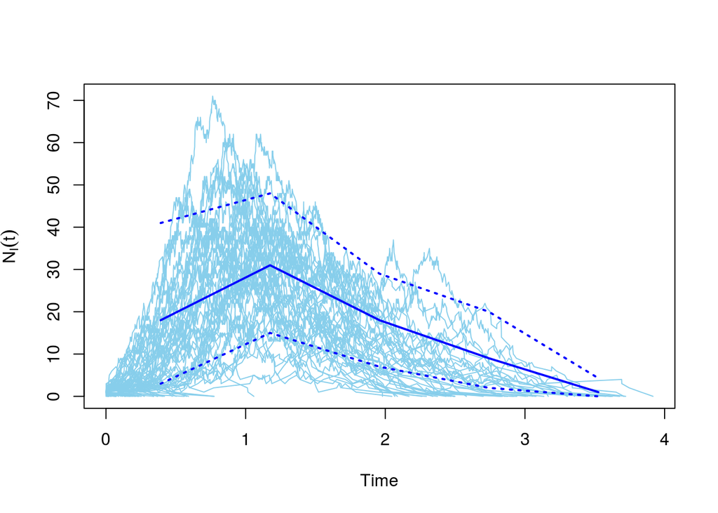

```r
plot(sim$er)
```

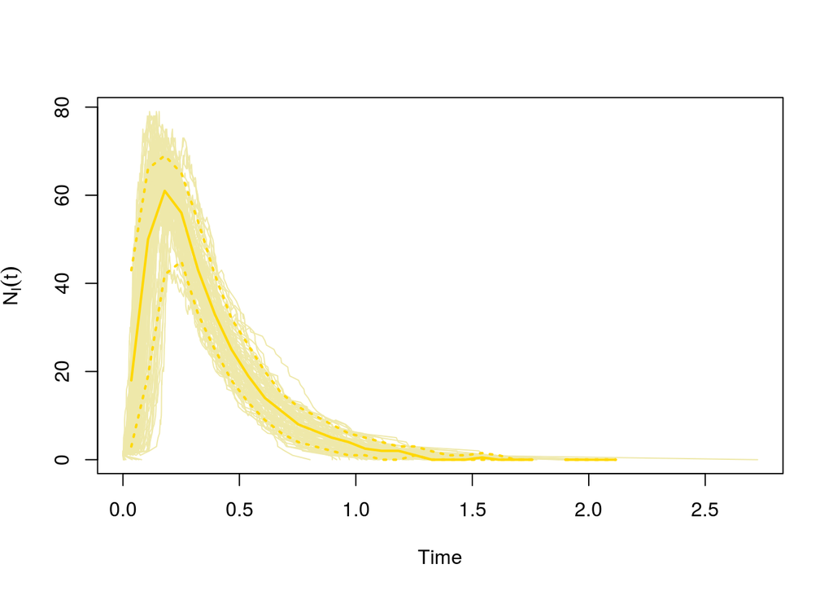

```r
plot(sim$ba, color="palegoldenrod", median_color="gold", quantile_color="gold")
```

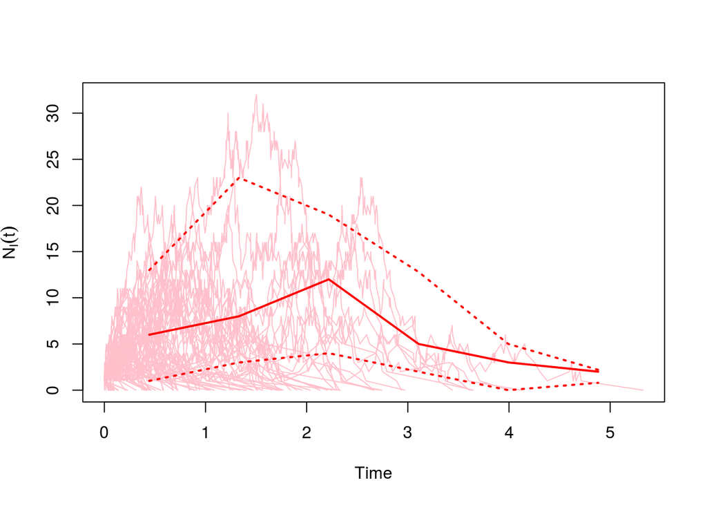

```r
plot(sim$ws, color="pink", median_color="red", quantile_color="red")
```

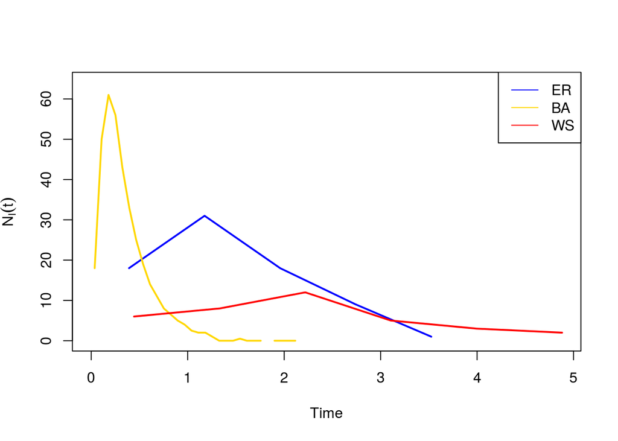

```r
x.max <- max(sapply(sapply(sim, time_bins), max))
y.max <- 1.05 * max(sapply(sapply(sim, function(x) median(x)[["NI"]]), max, na.rm=TRUE))

plot(time_bins(sim$er), median(sim$er)[["NI"]], type="l", lwd=2, col="blue", xlim=c(0, x.max), ylim=c(0, y.max), xlab="Time", ylab=expression(N[I](t)))
lines(time_bins(sim$ba), median(sim$ba)[["NI"]], lwd=2, col="gold")
lines(time_bins(sim$ws), median(sim$ws)[["NI"]],lwd=2, col="red")
legend("topright", c("ER", "BA", "WS"),col=c("blue", "gold", "red"), lty=1)
```

You need to plot three values on the graphics: Number of infected, number of suseprible, number of recovered - all depends on time. As a result of this task, you need to provide 12 plots (one for each network with 3 diferent parameters) with explanation.